# PSET 04 - Linear regression, Poisson Regression

#### 9. Suppose we want to quickly determine if the number of Level 2 charging stations in a census track looks roughly Poisson. (For this problem, consider all the data at once, not just the data for smaller subsets of $x$.) Let’s compare the data to a Poisson distribution with the same mean as the data. Plot the actual distribution of the data along with this Poisson distribution in a way that allows for a quick comparison of the two. Does the number pairs of Level 2 charging stations in a census tract look Poisson distributed?

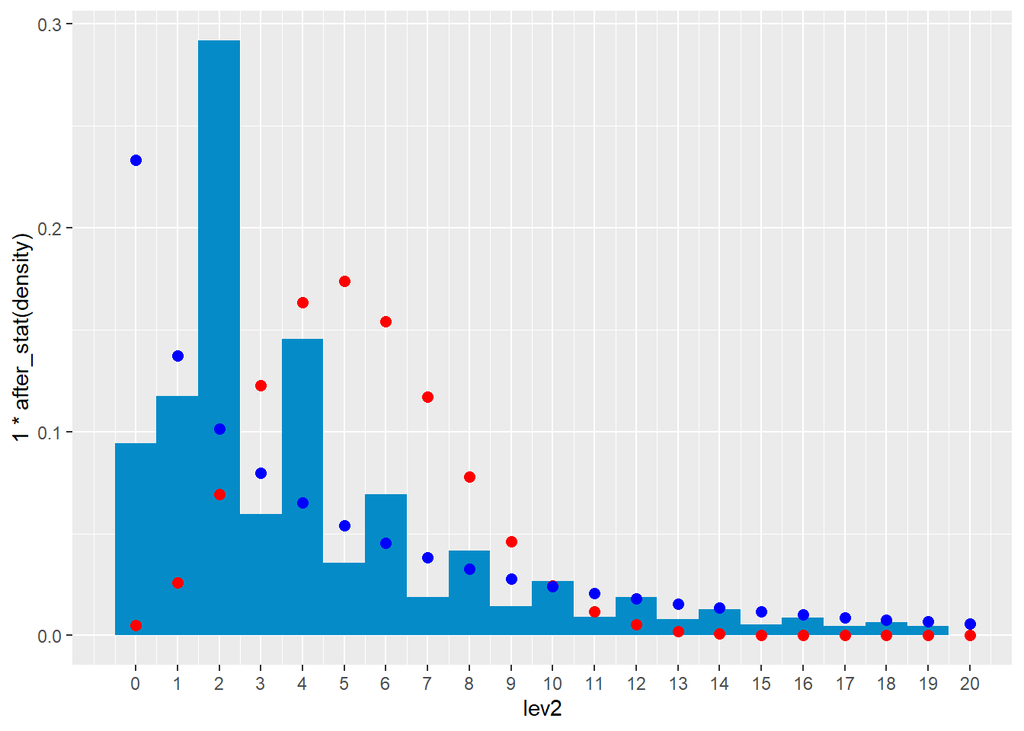

```r
#dc = dc[dc$lev2!=0,]
mu= mean(dc$lev2, na.rm=T)
v =  var(dc$lev2, na.rm=T)
dp = data.frame(x  =         0:20,
                y  =   dpois(0:20, lambda = mu),
                y2 = dnbinom(0:20, mu     = mu, size=mu^2/(v-mu)))

ggplot(dc, aes(x=lev2, y=1*after_stat(density)))+
  geom_histogram(binwidth=1) +
  geom_point(data=dp, aes(x=x, y=y), color='red')+
  geom_point(data=dp, aes(x=x, y=y2), color='blue')+
  scale_x_continuous(breaks=0:20, limits=c(NA,20))
```

Not Poisson. First the mean isn’t anywhere close to the variance.

```r
mu
```

```
## [1] 5.32209
```

```r
v
```

```
## [1] 48.21059
```

(Of course, the mean only needs to be equal to the variance for a given value of the predictor(s) if we want to use Poisson regression, so this alone doesn’t mean that Poisson would be bad. But there are other issues too.)

Even if we plot “pairs of Level 2 chargers”, the distribution still isn’t smooth.

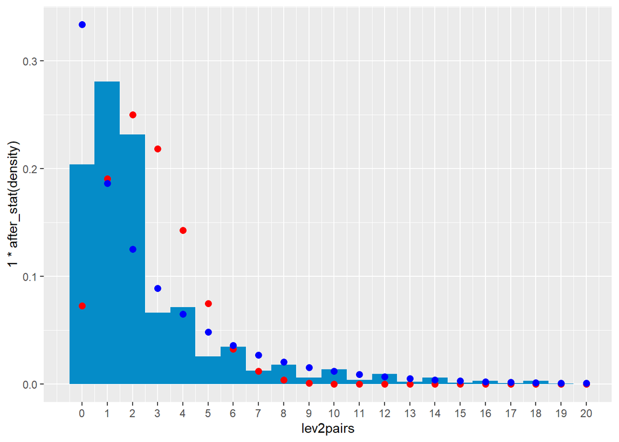

```r
mu= mean(dc$lev2pairs, na.rm=T)
v =  var(dc$lev2pairs, na.rm=T)
dp = data.frame(x  =         0:20,
                y  =   dpois(0:20, lambda = mu),
                y2 = dnbinom(0:20, mu     = mu, size=mu^2/(v-mu)))

ggplot(dc,
       aes(x = lev2pairs,
           y = 1*after_stat(density)))+
  geom_histogram(binwidth = 1) +
  geom_point(data=dp, aes(x=x, y=y), color='red')+
  geom_point(data=dp, aes(x=x, y=y2), color='blue')+
  scale_x_continuous(breaks=0:20, limits=c(NA,20))
```

Note that in the above graphs I also plotted negative binomial with the same mean and variance as the data. That looks better, but still doesn’t match the lumpiness.

Let’s do Level 3 for fun, even though the question doesn’t ask about it.

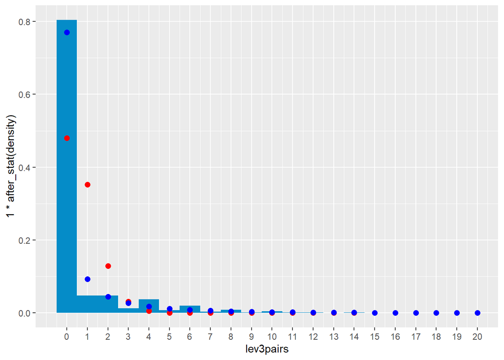

```r
#dc = dc[dc$lev3pairs!=0,]
mu= mean(dc$lev3pairs, na.rm=T)
v =  var(dc$lev3pairs, na.rm=T)
dp = data.frame(x  =         0:20,
                y  =   dpois(0:20, lambda = mu),
                y2 = dnbinom(0:20, mu     = mu, size=mu^2/(v-mu)))

ggplot(dc, aes(x=lev3pairs, y=1*after_stat(density)))+
  geom_histogram(binwidth=1) +
  geom_point(data=dp, aes(x=x, y=y), color='red')+
  geom_point(data=dp, aes(x=x, y=y2), color='blue')+
  scale_x_continuous(breaks=0:20, limits=c(NA,20))
```

```r
mu
```

```
## [1] 0.734772
```

```r
v
```

```
## [1] 4.45542
```

Negative binomial looks better for this one.

#### 10. Fit a Poisson Regression model for predicting Level 2 charging stations in a census tract using `house.value` and `age`. How does this model compare to the null model (the model with only an intercept term)? Considering your observations in #9, what outputs of this model are reasonable/unreasonable?

```r
glm1 = glm(lev2 ~  house.value + age ,
           data=dc,
           family='poisson')
summary(glm1)
```

```
##
## Call:
## glm(formula = lev2 ~ house.value + age, family = "poisson", data = dc)
##
## Coefficients:
##               Estimate Std. Error z value Pr(>|z|)
## (Intercept)  1.934e+00  1.667e-02  116.05   <2e-16 ***
## house.value  7.120e-07  8.887e-09   80.11   <2e-16 ***
## age         -1.389e-02  4.245e-04  -32.71   <2e-16 ***
## ---
## Signif. codes:  0 '***' 0.001 '**' 0.01 '*' 0.05 '.' 0.1 ' ' 1
##
## (Dispersion parameter for poisson family taken to be 1)
##
##     Null deviance: 104687  on 17507  degrees of freedom
## Residual deviance:  98841  on 17505  degrees of freedom
##   (518 observations deleted due to missingness)
## AIC: 149761
##
## Number of Fisher Scoring iterations: 5
```

The coefficients are significant, and the deviance is much lower than it is for the null model, so the model seems useful. The `house.value` coefficient is positive, as we might expect. The `age` coefficient is negative. This might be because of collinearity with `house.value`, or could be because younger drivers are more likely to own an electric vehicle, and charging stations get installed in census tracts with lower median age.

Let’s try this with log(pop) as a predictor and with log(pop) as an offset (coefficient fixed to 1), just for fun.

```r
glm2 = glm(lev2 ~  house.value + age +        log(pop) , data=dc, family='poisson')
glm3 = glm(lev2 ~  house.value + age , offset=log(pop) , data=dc, family='poisson')
glm4 = glm(lev2 ~  house.value + age + offset(log(pop)), data=dc, family='poisson')

summary(glm1)$coef
```

```
##                  Estimate   Std. Error   z value      Pr(>|z|)
## (Intercept)  1.934244e+00 1.666759e-02 116.04825  0.000000e+00
## house.value  7.119524e-07 8.887025e-09  80.11144  0.000000e+00
## age         -1.388685e-02 4.245435e-04 -32.71007 1.123123e-234
```

```r
summary(glm2)$coef
```

```
##                  Estimate   Std. Error    z value      Pr(>|z|)
## (Intercept)  1.739615e+00 6.292418e-02  27.646211 3.099402e-168
## house.value  7.119019e-07 8.895052e-09  80.033476  0.000000e+00
## age         -1.362987e-02 4.324839e-04 -31.515331 5.356176e-218
## log(pop)     2.194345e-02 6.838495e-03   3.208813  1.332843e-03
```

```r
summary(glm3)$coef
```

```
##                  Estimate   Std. Error    z value     Pr(>|z|)
## (Intercept) -7.072032e+00 1.732832e-02 -408.11975 0.0000000000
## house.value  7.238379e-07 9.264749e-09   78.12817 0.0000000000
## age         -1.639795e-03 4.419598e-04   -3.71028 0.0002070301
```

```r
summary(glm4)$coef
```

```
##                  Estimate   Std. Error    z value     Pr(>|z|)
## (Intercept) -7.072032e+00 1.732832e-02 -408.11975 0.0000000000
## house.value  7.238379e-07 9.264749e-09   78.12817 0.0000000000
## age         -1.639795e-03 4.419598e-04   -3.71028 0.0002070301
```

```r
summary(glm1)$deviance
```

```
## [1] 98841.08
```

```r
summary(glm2)$deviance
```

```
## [1] 98830.76
```

```r
summary(glm3)$deviance
```

```
## [1] 118471.1
```

```r
summary(glm4)$deviance
```

```
## [1] 118471.1
```